# A5 Means and SD’s across RRP

Gerko Vink

# Packages used

For this document we use the following packages

```r
library(dplyr)    # Data manipulation
library(mice)     # Data imputation
library(magrittr) # Pipes
library(purrr)    # Functional programming
library(haven)    # Import data
library(DT)       # Interactive tables
library(ggplot2)  # Plotting device
library(reshape2) # Data shaping
library(labelled) # Advanced labelling
library(psych)    # Descriptives
library(tibble)   # Dataframes on steroids
library(gtools)   # Useful tools
library(DT)       # HTML tables
```

# Load the data

```r
load(file = "../Workspaces/3. Data imputation.Rdata")
load(file = "../Workspaces/2. Data inspection.Rdata")
```

# RRP with and without `NA`’s

We consider **both the cases with and without `Not Applicable`’s** in this document. First, we create an indicator for all RRP

```r
RRP_set <- names(raw_data[86:107])[c(1, 2, 4, 6, 9, 12, 15, 16, 17, 19, 21 )]
```

## Descriptives and plots

### Overall

First, we calculate the descriptive statistics of the data **with `Not Applicable`’s**

```r
mice::complete(imp, 1) %>% #RRP has no missings -so use 1st imputed set
  select(all_of(RRP_set)) %>%
  rowMeans(na.rm = FALSE) %>% #no missings
  describe() %>% .[, 2:5] %>%
  print.data.frame()
```

```
##       n     mean       sd   median
## X1 6813 4.581562 1.163845 4.727273
```

Second, we print the means and SD’s for the data without the rows that contain `Not Applicable`’s.

```r
mice::complete(imp, 1) %>% #RRP has no missings -so use 1st imputed set
  select(all_of(RRP_set)) %>%
  na_if(0) %>%
  rowMeans(na.rm = FALSE) %>% #i.e. listwise deletion of incomplete rows
  describe() %>% .[, 2:5] %>%
  print.data.frame()
```

```
##       n     mean        sd   median
## X1 1893 5.459204 0.7196349 5.545455
```

Third, we consider the means and SD’s for the RRP’s for the data without the rows that contain `Not Applicable`’s where for each row the mean is calculated based on the observed (i.e. applicable) values.

```r
mice::complete(imp, 1) %>% #RRP has no missings -so use 1st imputed set
  select(all_of(RRP_set)) %>%
  na_if(0) %>%
  rowMeans(na.rm = TRUE) %>% #i.e. casewise deletion of unobserved values in row
  describe() %>% .[, 2:5] %>%
  print.data.frame()
```

```
##       n     mean        sd median
## X1 6774 5.556312 0.7503754    5.6
```

### By disciplinary field

First, we calculate the descriptive statistics of the data **with `Not Applicable`’s**

```
##                                 D2 count     mean       sd
## 1   Social and Behavioral Sciences  1965 4.516771 1.157085
## 2              Arts and Humanities   636 3.868353 1.309557
## 3 Engineering and Natural Sciences  1465 4.634130 1.136992
## 4     Biomedical and Life Sciences  2747 4.765000 1.077444
```

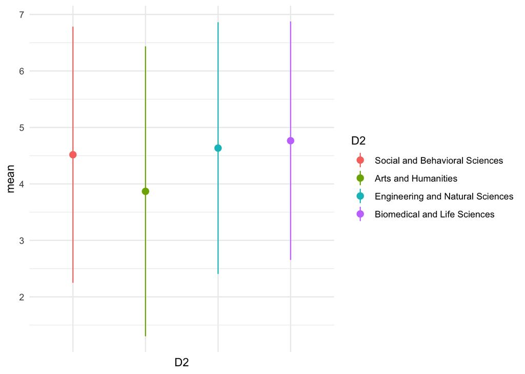

```r
mice::complete(imp, 1) %>% #RRP has no missings -so use 1st imputed set
  select(D2, all_of(RRP_set)) %>%
  mutate(rowM = rowMeans(select(., all_of(RRP_set)), na.rm = FALSE)) %>%
  select(D2, rowM) %>%
  melt(id.vars = "D2", value.name = "RRP_mean") %>%
  group_by(D2) %>%
  summarise(count = n(),
            mean = mean(RRP_mean, na.rm=TRUE),
            sd = sd(RRP_mean, na.rm = TRUE))  %T>%
  print.data.frame() %>%
  ggplot(aes(x = D2, y = mean,
             ymin = mean - 1.96*sd,
             ymax = mean + 1.96*sd)) +
  geom_pointrange(aes(group = D2, colour = D2),
                  position = position_dodge(width = 1)) +
  theme_minimal() +
  theme(axis.text.x = element_blank(), axis.ticks = element_blank())
```

Second, we print the means and SD’s for the data without the rows that contain `Not Applicable`’s.

```
##                                 D2 count     mean        sd
## 1   Social and Behavioral Sciences  1965 5.403629 0.7593028
## 2              Arts and Humanities   636 5.380383 0.8621468
## 3 Engineering and Natural Sciences  1465 5.466026 0.7202327
## 4     Biomedical and Life Sciences  2747 5.494275 0.6811974
```

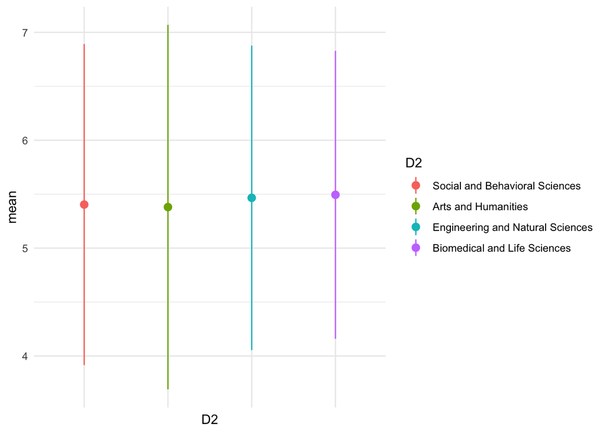

```r
mice::complete(imp, 1) %>% #RRP has no missings -so use 1st imputed set
  select(D2, all_of(RRP_set)) %>%
  na_if(0) %>%
  mutate(rowM = rowMeans(select(., all_of(RRP_set)), na.rm = FALSE)) %>%
  select(D2, rowM) %>%
  melt(id.vars = "D2", value.name = "RRP_mean") %>%
  group_by(D2) %>%
  summarise(count = n(),
            mean = mean(RRP_mean, na.rm=TRUE),
            sd = sd(RRP_mean, na.rm = TRUE))  %T>%
  print.data.frame() %>%
  ggplot(aes(x = D2, y = mean,
             ymin = mean - 1.96*sd,
             ymax = mean + 1.96*sd)) +
  geom_pointrange(aes(group = D2, colour = D2),
                  position = position_dodge(width = 1)) +
  theme_minimal() +
  theme(axis.text.x = element_blank(), axis.ticks = element_blank())
```

Third, we consider the means and SD’s for the RRP’s where only missing cases are excluded from calculating the rowwise mean.

```
##                                 D2 count     mean        sd
## 1   Social and Behavioral Sciences  1965 5.488399 0.7703083
## 2              Arts and Humanities   636 5.733873 0.7869678
## 3 Engineering and Natural Sciences  1465 5.595169 0.7714691
## 4     Biomedical and Life Sciences  2747 5.543268 0.7073557
```

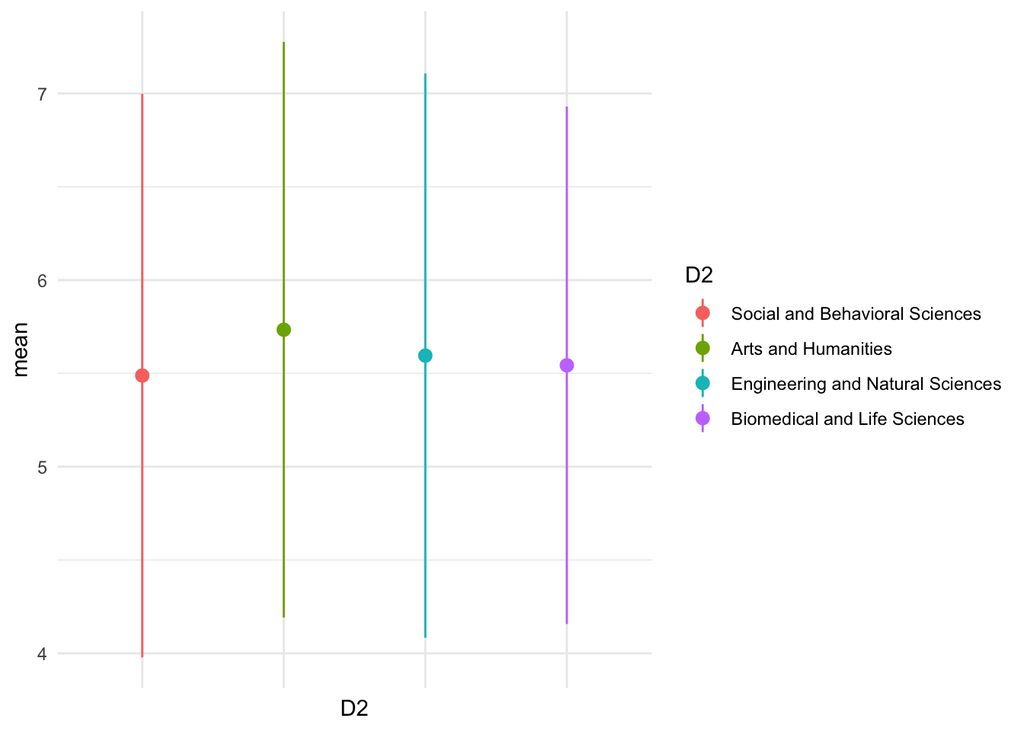

```r
mice::complete(imp, 1) %>% #RRP has no missings -so use 1st imputed set
  select(D2, all_of(RRP_set)) %>%
  na_if(0) %>%
  mutate(rowM = rowMeans(select(., all_of(RRP_set)), na.rm = TRUE)) %>%
  select(D2, rowM) %>%
  melt(id.vars = "D2", value.name = "RRP_mean") %>%
  group_by(D2) %>%
  summarise(count = n(),
            mean = mean(RRP_mean, na.rm=TRUE),
            sd = sd(RRP_mean, na.rm = TRUE)) %T>%
  print.data.frame() %>%
  ggplot(aes(x = D2, y = mean,
             ymin = mean - 1.96*sd,
             ymax = mean + 1.96*sd)) +
  geom_pointrange(aes(group = D2, colour = D2),
                  position = position_dodge(width = 1)) +
  theme_minimal() +
  theme(axis.text.x = element_blank(), axis.ticks = element_blank())
```

### By rank

First, we calculate the descriptive statistics of the data **with `Not Applicable`’s**

```
##                                                                                          D3
## 1                                                          PhD student or junior researcher
## 2 Postdoctoral researcher, Assistant Professor, Physician Researcher or Lecturer Researcher
## 3                                                     Associate Professor or Full Professor
##   count     mean        sd
## 1  2013 4.168180 1.4175798
## 2  2733 4.719855 0.9830165
## 3  2067 4.801293 0.9956034
```

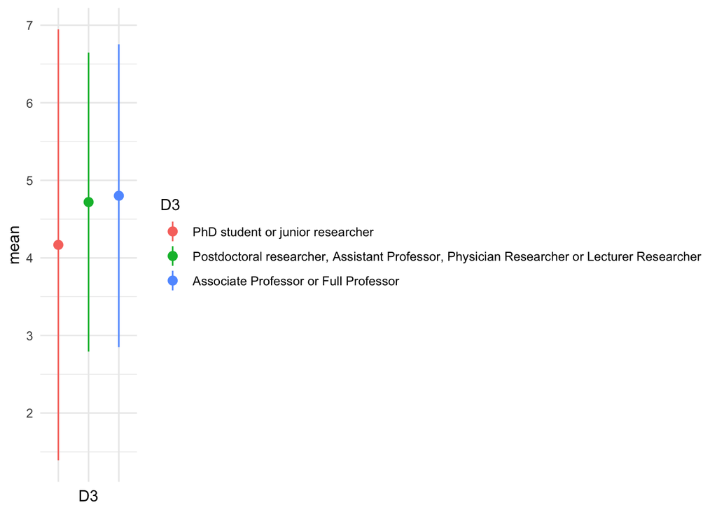

```r
mice::complete(imp, 1) %>% #RRP has no missings -so use 1st imputed set
  select(D3, all_of(RRP_set)) %>%
  mutate(rowM = rowMeans(select(., all_of(RRP_set)), na.rm = FALSE)) %>%
  select(D3, rowM) %>%
  melt(id.vars = "D3", value.name = "RRP_mean") %>%
  group_by(D3) %>%
  summarise(count = n(),
            mean = mean(RRP_mean, na.rm=TRUE),
            sd = sd(RRP_mean, na.rm = TRUE))  %T>%
  print.data.frame() %>%
  ggplot(aes(x = D3, y = mean,
             ymin = mean - 1.96*sd,
             ymax = mean + 1.96*sd)) +
  geom_pointrange(aes(group = D3, colour = D3),
                  position = position_dodge(width = 1)) +
  theme_minimal() +
  theme(axis.text.x = element_blank(), axis.ticks = element_blank())
```

Second, we print the means and SD’s for the data without the rows that contain `Not Applicable`’s.

```
##                                                                                          D3
## 1                                                          PhD student or junior researcher
## 2 Postdoctoral researcher, Assistant Professor, Physician Researcher or Lecturer Researcher
## 3                                                     Associate Professor or Full Professor
##   count     mean        sd
## 1  2013 5.418226 0.8131043
## 2  2733 5.421394 0.7166795
## 3  2067 5.528259 0.6559120
```

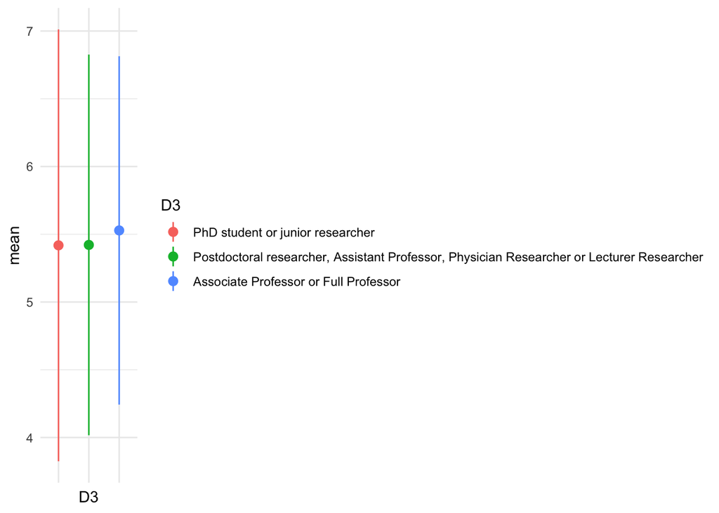

```r
mice::complete(imp, 1) %>% #RRP has no missings -so use 1st imputed set
  select(D3, all_of(RRP_set)) %>%
  na_if(0) %>%
  mutate(rowM = rowMeans(select(., all_of(RRP_set)), na.rm = FALSE)) %>%
  select(D3, rowM) %>%
  melt(id.vars = "D3", value.name = "RRP_mean") %>%
  group_by(D3) %>%
  summarise(count = n(),
            mean = mean(RRP_mean, na.rm=TRUE),
            sd = sd(RRP_mean, na.rm = TRUE))  %T>%
  print.data.frame() %>%
  ggplot(aes(x = D3, y = mean,
             ymin = mean - 1.96*sd,
             ymax = mean + 1.96*sd)) +
  geom_pointrange(aes(group = D3, colour = D3),
                  position = position_dodge(width = 1)) +
  theme_minimal() +
  theme(axis.text.x = element_blank(), axis.ticks = element_blank())
```

Third, we consider the means and SD’s for the RRP’s where only missing cases are excluded from calculating the rowwise mean.

```
##                                                                                          D3
## 1                                                          PhD student or junior researcher
## 2 Postdoctoral researcher, Assistant Professor, Physician Researcher or Lecturer Researcher
## 3                                                     Associate Professor or Full Professor
##   count     mean        sd
## 1  2013 5.553667 0.8274014
## 2  2733 5.518175 0.7299153
## 3  2067 5.609237 0.6946594
```

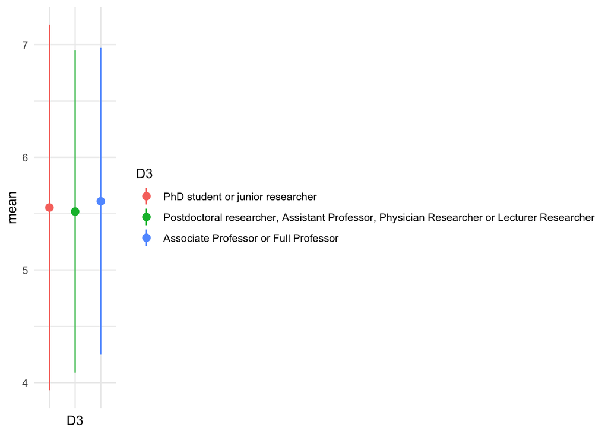

```r
mice::complete(imp, 1) %>% #RRP has no missings -so use 1st imputed set
  select(D3, all_of(RRP_set)) %>%
  na_if(0) %>%
  mutate(rowM = rowMeans(select(., all_of(RRP_set)), na.rm = TRUE)) %>%
  select(D3, rowM) %>%
  melt(id.vars = "D3", value.name = "RRP_mean") %>%
  group_by(D3) %>%
  summarise(count = n(),
            mean = mean(RRP_mean, na.rm=TRUE),
            sd = sd(RRP_mean, na.rm = TRUE)) %T>%
  print.data.frame() %>%
  ggplot(aes(x = D3, y = mean,
             ymin = mean - 1.96*sd,
             ymax = mean + 1.96*sd)) +
  geom_pointrange(aes(group = D3, colour = D3),
                  position = position_dodge(width = 1)) +
  theme_minimal() +
  theme(axis.text.x = element_blank(), axis.ticks = element_blank())
```

### By gender identification

First, we calculate the descriptive statistics of the data **with `Not Applicable`’s**

```
##                                D4 count     mean       sd
## 1                          Female  3008 4.497764 1.203262
## 2                            Male  3689 4.649696 1.127582
## 3 Other / Do not wish to disclose   116 4.587774 1.127224
```

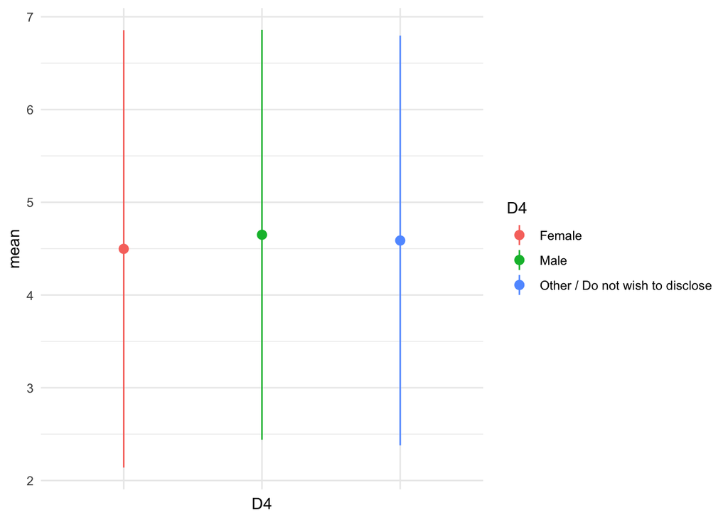

```r
mice::complete(imp, 1) %>% #RRP has no missings -so use 1st imputed set
  select(D4, all_of(RRP_set)) %>%
  mutate(rowM = rowMeans(select(., all_of(RRP_set)), na.rm = FALSE)) %>%
  select(D4, rowM) %>%
  melt(id.vars = "D4", value.name = "RRP_mean") %>%
  group_by(D4) %>%
  summarise(count = n(),
            mean = mean(RRP_mean, na.rm=TRUE),
            sd = sd(RRP_mean, na.rm = TRUE))  %T>%
  print.data.frame() %>%
  ggplot(aes(x = D4, y = mean,
             ymin = mean - 1.96*sd,
             ymax = mean + 1.96*sd)) +
  geom_pointrange(aes(group = D4, colour = D4),
                  position = position_dodge(width = 1)) +
  theme_minimal() +
  theme(axis.text.x = element_blank(), axis.ticks = element_blank())
```

Second, we print the means and SD’s for the data without the rows that contain `Not Applicable`’s.

```
##                                D4 count     mean        sd
## 1                          Female  3008 5.440304 0.6963975
## 2                            Male  3689 5.470579 0.7351903
## 3 Other / Do not wish to disclose   116 5.531987 0.7401413
```

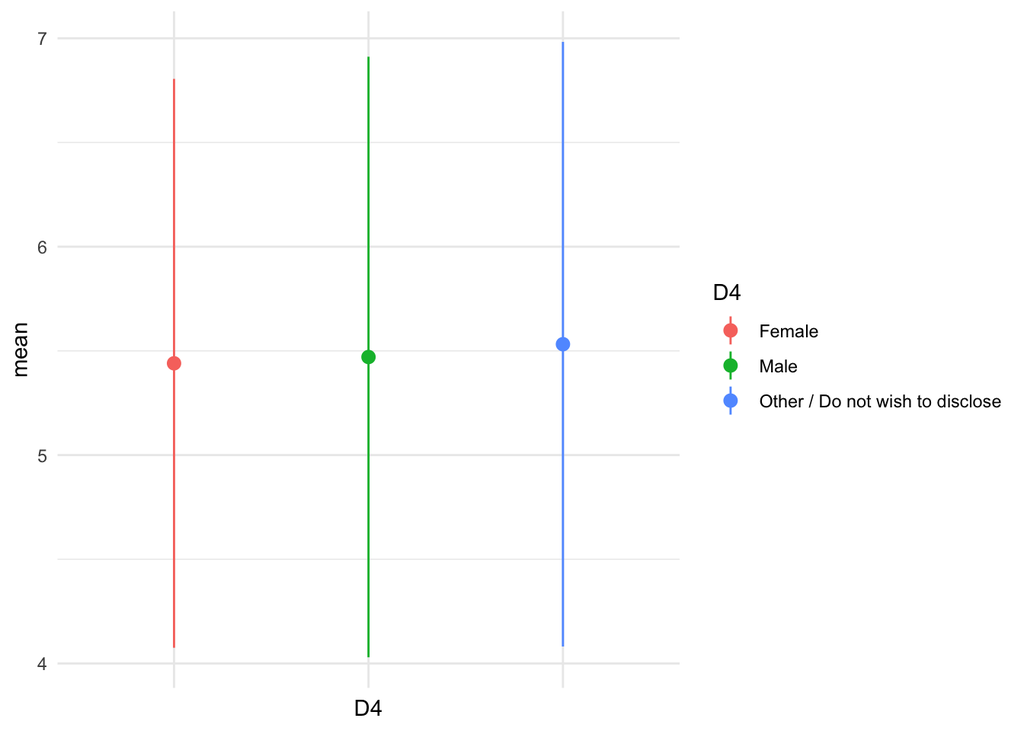

```r
mice::complete(imp, 1) %>% #RRP has no missings -so use 1st imputed set
  select(D4, all_of(RRP_set)) %>%
  na_if(0) %>%
  mutate(rowM = rowMeans(select(., all_of(RRP_set)), na.rm = FALSE)) %>%
  select(D4, rowM) %>%
  melt(id.vars = "D4", value.name = "RRP_mean") %>%
  group_by(D4) %>%
  summarise(count = n(),
            mean = mean(RRP_mean, na.rm=TRUE),
            sd = sd(RRP_mean, na.rm = TRUE))  %T>%
  print.data.frame() %>%
  ggplot(aes(x = D4, y = mean,
             ymin = mean - 1.96*sd,
             ymax = mean + 1.96*sd)) +
  geom_pointrange(aes(group = D4, colour = D4),
                  position = position_dodge(width = 1)) +
  theme_minimal() +
  theme(axis.text.x = element_blank(), axis.ticks = element_blank())
```

Third, we consider the means and SD’s for the RRP’s where only missing cases are excluded from calculating the rowwise mean.

```
##                                D4 count     mean        sd
## 1                          Female  3008 5.551475 0.7448219
## 2                            Male  3689 5.554746 0.7555651
## 3 Other / Do not wish to disclose   116 5.730386 0.7125038
```

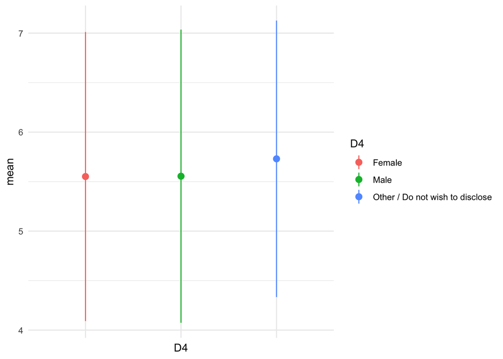

```r
mice::complete(imp, 1) %>% #RRP has no missings -so use 1st imputed set
  select(D4, all_of(RRP_set)) %>%
  na_if(0) %>%
  mutate(rowM = rowMeans(select(., all_of(RRP_set)), na.rm = TRUE)) %>%
  select(D4, rowM) %>%
  melt(id.vars = "D4", value.name = "RRP_mean") %>%
  group_by(D4) %>%
  summarise(count = n(),
            mean = mean(RRP_mean, na.rm=TRUE),
            sd = sd(RRP_mean, na.rm = TRUE)) %T>%
  print.data.frame() %>%
  ggplot(aes(x = D4, y = mean,
             ymin = mean - 1.96*sd,
             ymax = mean + 1.96*sd)) +
  geom_pointrange(aes(group = D4, colour = D4),
                  position = position_dodge(width = 1)) +
  theme_minimal() +
  theme(axis.text.x = element_blank(), axis.ticks = element_blank())
```

### By empirical research engagement

First, we calculate the descriptive statistics of the data **with `Not Applicable`’s**

```
##    D5 count     mean       sd
## 1 Yes  6083 4.678523 1.093277
## 2  No   730 3.773599 1.397539
```

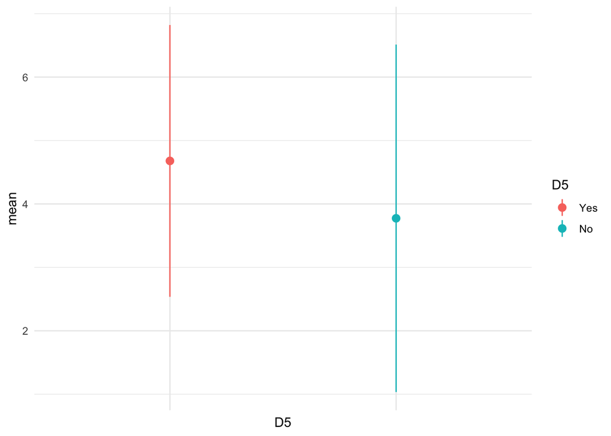

```r
mice::complete(imp, 1) %>% #RRP has no missings -so use 1st imputed set
  select(D5, all_of(RRP_set)) %>%
  mutate(rowM = rowMeans(select(., all_of(RRP_set)), na.rm = FALSE)) %>%
  select(D5, rowM) %>%
  melt(id.vars = "D5", value.name = "RRP_mean") %>%
  group_by(D5) %>%
  summarise(count = n(),
            mean = mean(RRP_mean, na.rm=TRUE),
            sd = sd(RRP_mean, na.rm = TRUE))  %T>%
  print.data.frame() %>%
  ggplot(aes(x = D5, y = mean,
             ymin = mean - 1.96*sd,
             ymax = mean + 1.96*sd)) +
  geom_pointrange(aes(group = D5, colour = D5),
                  position = position_dodge(width = 1)) +
  theme_minimal() +
  theme(axis.text.x = element_blank(), axis.ticks = element_blank())
```

Second, we print the means and SD’s for the data without the rows that contain `Not Applicable`’s.

```
##    D5 count     mean        sd
## 1 Yes  6083 5.466821 0.7122526
## 2  No   730 5.299154 0.8493603
```

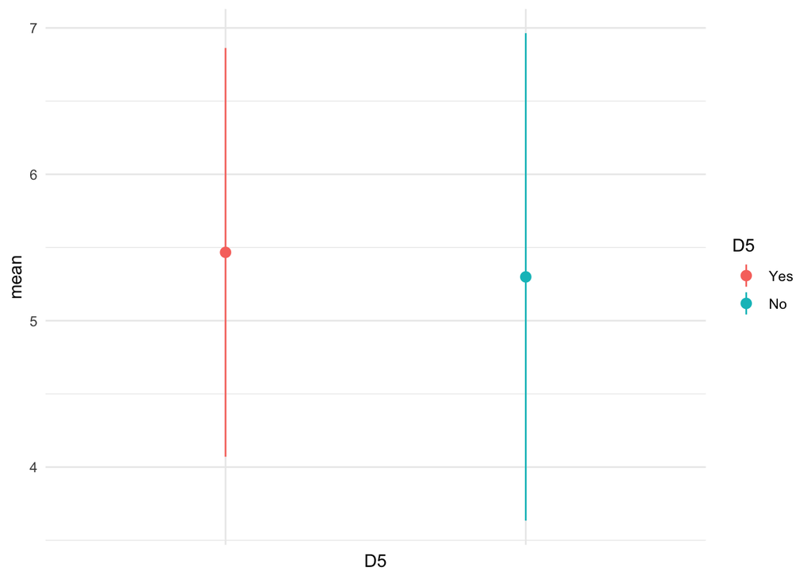

```r
mice::complete(imp, 1) %>% #RRP has no missings -so use 1st imputed set
  select(D5, all_of(RRP_set)) %>%
  na_if(0) %>%
  mutate(rowM = rowMeans(select(., all_of(RRP_set)), na.rm = FALSE)) %>%
  select(D5, rowM) %>%
  melt(id.vars = "D5", value.name = "RRP_mean") %>%
  group_by(D5) %>%
  summarise(count = n(),
            mean = mean(RRP_mean, na.rm=TRUE),
            sd = sd(RRP_mean, na.rm = TRUE))  %T>%
  print.data.frame() %>%
  ggplot(aes(x = D5, y = mean,
             ymin = mean - 1.96*sd,
             ymax = mean + 1.96*sd)) +
  geom_pointrange(aes(group = D5, colour = D5),
                  position = position_dodge(width = 1)) +
  theme_minimal() +
  theme(axis.text.x = element_blank(), axis.ticks = element_blank())
```

Third, we consider the means and SD’s for the RRP’s where only missing cases are excluded from calculating the rowwise mean.

```
##    D5 count     mean        sd
## 1 Yes  6083 5.540335 0.7368653
## 2  No   730 5.691281 0.8446270
```

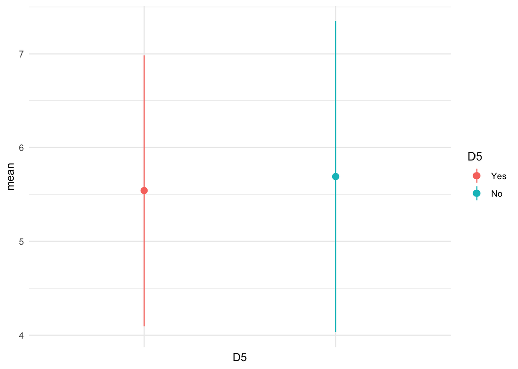

```r
mice::complete(imp, 1) %>% #RRP has no missings -so use 1st imputed set
  select(D5, all_of(RRP_set)) %>%
  na_if(0) %>%
  mutate(rowM = rowMeans(select(., all_of(RRP_set)), na.rm = TRUE)) %>%
  select(D5, rowM) %>%
  melt(id.vars = "D5", value.name = "RRP_mean") %>%
  group_by(D5) %>%
  summarise(count = n(),
            mean = mean(RRP_mean, na.rm=TRUE),
            sd = sd(RRP_mean, na.rm = TRUE)) %T>%
  print.data.frame() %>%
  ggplot(aes(x = D5, y = mean,
             ymin = mean - 1.96*sd,
             ymax = mean + 1.96*sd)) +
  geom_pointrange(aes(group = D5, colour = D5),
                  position = position_dodge(width = 1)) +
  theme_minimal() +
  theme(axis.text.x = element_blank(), axis.ticks = element_blank())
```

### By institutional support

First, we calculate the descriptive statistics of the data **with `Not Applicable`’s**

```
##               Group count     mean       sd
## 1     Joining group  3270 4.513289 1.214823
## 2 Non-joining group  3543 4.644574 1.111184
```

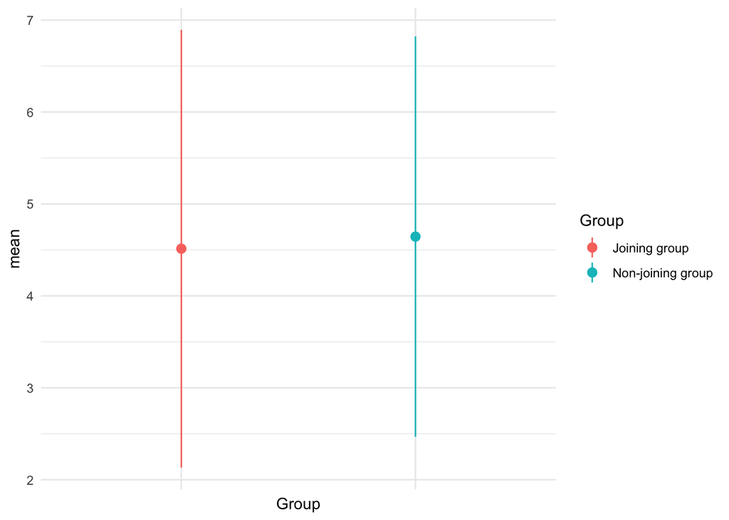

```r
mice::complete(imp, 1) %>% #RRP has no missings -so use 1st imputed set
  select(Group, all_of(RRP_set)) %>%
  mutate(rowM = rowMeans(select(., all_of(RRP_set)), na.rm = FALSE)) %>%
  select(Group, rowM) %>%
  melt(id.vars = "Group", value.name = "RRP_mean") %>%
  group_by(Group) %>%
  summarise(count = n(),
            mean = mean(RRP_mean, na.rm=TRUE),
            sd = sd(RRP_mean, na.rm = TRUE))  %T>%
  print.data.frame() %>%
  ggplot(aes(x = Group, y = mean,
             ymin = mean - 1.96*sd,
             ymax = mean + 1.96*sd)) +
  geom_pointrange(aes(group = Group, colour = Group),
                  position = position_dodge(width = 1)) +
  theme_minimal() +
  theme(axis.text.x = element_blank(), axis.ticks = element_blank())
```

Second, we print the means and SD’s for the data without the rows that contain `Not Applicable`’s.

```
##               Group count     mean        sd
## 1     Joining group  3270 5.424731 0.7284992
## 2 Non-joining group  3543 5.488459 0.7110715
```

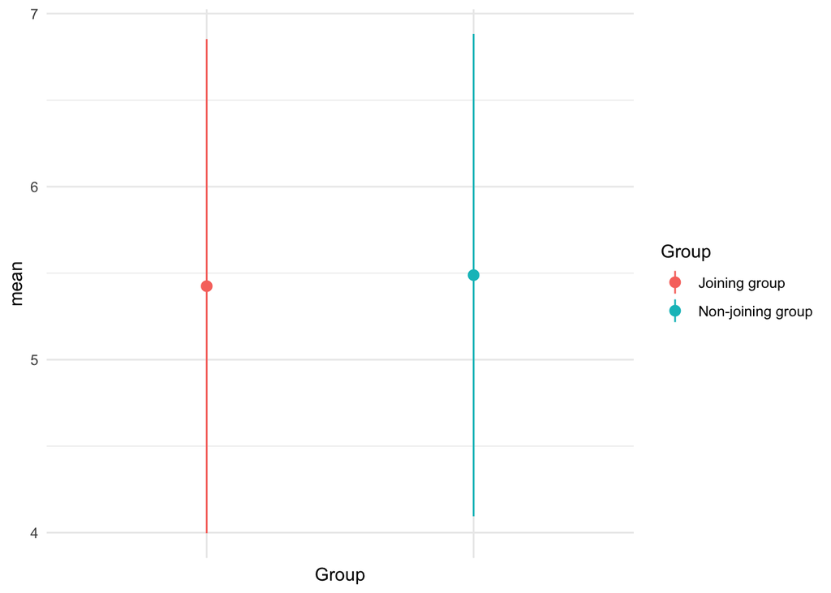

```r
mice::complete(imp, 1) %>% #RRP has no missings -so use 1st imputed set
  select(Group, all_of(RRP_set)) %>%
  na_if(0) %>%
  mutate(rowM = rowMeans(select(., all_of(RRP_set)), na.rm = FALSE)) %>%
  select(Group, rowM) %>%
  melt(id.vars = "Group", value.name = "RRP_mean") %>%
  group_by(Group) %>%
  summarise(count = n(),
            mean = mean(RRP_mean, na.rm=TRUE),
            sd = sd(RRP_mean, na.rm = TRUE))  %T>%
  print.data.frame() %>%
  ggplot(aes(x = Group, y = mean,
             ymin = mean - 1.96*sd,
             ymax = mean + 1.96*sd)) +
  geom_pointrange(aes(group = Group, colour = Group),
                  position = position_dodge(width = 1)) +
  theme_minimal() +
  theme(axis.text.x = element_blank(), axis.ticks = element_blank())
```

Third, we consider the means and SD’s for the RRP’s where only missing cases are excluded from calculating the rowwise mean.

```
##               Group count     mean        sd
## 1     Joining group  3270 5.544228 0.7563512
## 2 Non-joining group  3543 5.567410 0.7447793
```

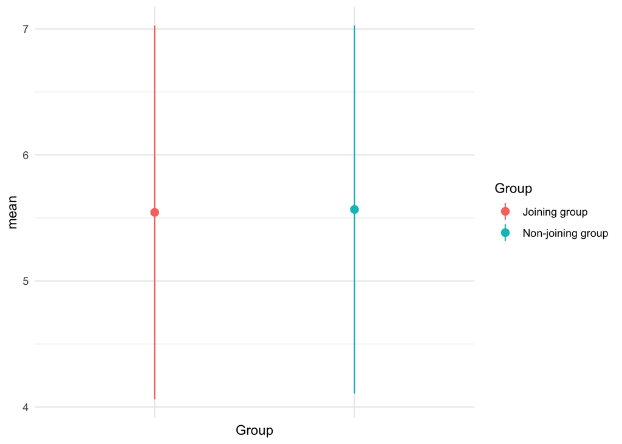

```r
mice::complete(imp, 1) %>% #RRP has no missings -so use 1st imputed set
  select(Group, all_of(RRP_set)) %>%
  na_if(0) %>%
  mutate(rowM = rowMeans(select(., all_of(RRP_set)), na.rm = TRUE)) %>%
  select(Group, rowM) %>%
  melt(id.vars = "Group", value.name = "RRP_mean") %>%
  group_by(Group) %>%
  summarise(count = n(),
            mean = mean(RRP_mean, na.rm=TRUE),
            sd = sd(RRP_mean, na.rm = TRUE)) %T>%
  print.data.frame() %>%
  ggplot(aes(x = Group, y = mean,
             ymin = mean - 1.96*sd,
             ymax = mean + 1.96*sd)) +
  geom_pointrange(aes(group = Group, colour = Group),
                  position = position_dodge(width = 1)) +
  theme_minimal() +
  theme(axis.text.x = element_blank(), axis.ticks = element_blank())
```

# Document info

Signed: [Gerko Vink](https://www.gerkovink.com),

```r
timestamp()
```

```
## ##------ Tue Apr  6 20:40:25 2021 ------##
```

END of DOCUMENT